# Survey Sampling Final Report

```r
t.test(response ~ gender, data = Q4_7_data, var.equal = FALSE)
```

```
##
##  Welch Two Sample t-test
##
## data:  response by gender
## t = 1.6949, df = 95.562, p-value = 0.09335
## alternative hypothesis: true difference in means between group 女 and group 男 is not equal to 0
## 95 percent confidence interval:
##  -0.05072219  0.64323555
## sample estimates:
## mean in group 女 mean in group 男
##         3.823529         3.527273
```

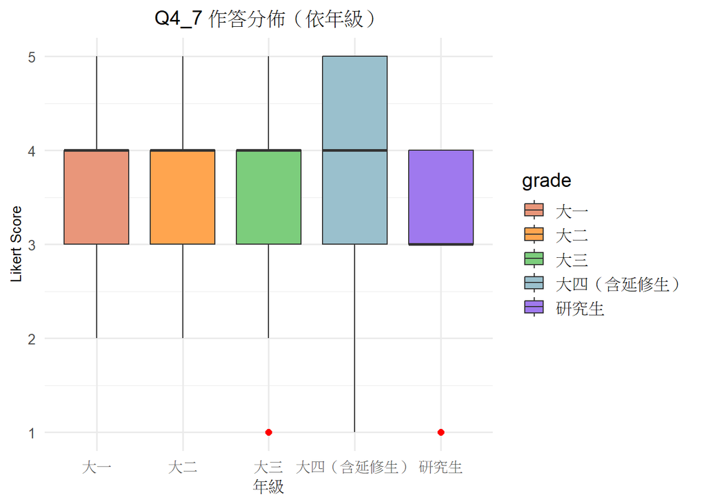

```
## # A tibble: 5 × 9
##   grade             mean variance    sd   min    Q1    Q2    Q3   max
##   <chr>            <dbl>    <dbl> <dbl> <dbl> <dbl> <dbl> <dbl> <dbl>
## 1 大一              3.56     1.17  1.08     2     3     4     4     5
## 2 大三              3.74     0.9   0.95     1     3     4     4     5
## 3 大二              3.8      0.87  0.93     2     3     4     4     5
## 4 大四（含延修生）  3.86     1.19  1.09     1     3     4     5     5
## 5 研究生            3.14     1.14  1.07     1     3     3     4     4
```

從 Q4_7 題目的年級分析結果來看，不同年級對「關稅上升導致非必要性商品變貴時是否會調整消費行為」的認同程度差異不大。雖然大四（含延修生）平均分數最高（3.86），研究生則相對偏低（3.14），但整體變異不大。

```r
#ANOVA Q4_7 grade

anova_result <- aov(response ~ grade, data = Q4_7_data)
summary(anova_result)
```

```
##              Df Sum Sq Mean Sq F value Pr(>F)
## grade         4    3.8  0.9500   0.951  0.436
## Residuals   152  151.9  0.9991
```

ANOVA 檢定的 p 值為 0.436，顯示年級與此題的回答並無顯著關聯，亦即不同年級的學生在此議題上的態度並無統計上顯著差異。

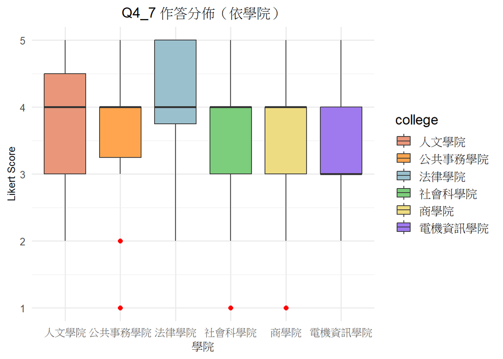

從不同學院的盒鬚圖來看，不同學院的中位數大部分落於 4，僅電資學院落於 3，所有學院的數據分布落於 3 ~ 5之間，可見整體的圖形來看幾乎無太大差異。

```
## # A tibble: 6 × 9
##   college       mean variance    sd   min    Q1    Q2    Q3   max
##   <chr>        <dbl>    <dbl> <dbl> <dbl> <dbl> <dbl> <dbl> <dbl>
## 1 人文學院      3.71     1.57  1.25     2  3        4   4.5     5
## 2 公共事務學院  3.8      0.79  0.89     1  3.25     4   4       5
## 3 商學院        3.68     1.04  1.02     1  3        4   4       5
## 4 法律學院      3.9      1.04  1.02     2  3.75     4   5       5
## 5 社會科學院    3.67     1.1   1.05     1  3        4   4       5
## 6 電機資訊學院  3.43     0.95  0.98     2  3        3   4       5
```

從 Q4_7 題目針對不同學院的分析來看，各學院學生對「當關稅導致非必要性商品變貴時是否會調整消費行為」的平均認同度相近，均落在 3.43 至 3.90 之間。雖然法律學院平均分數略高（3.90），電機資訊學院略低（3.43），但整體差異不明顯。

```r
#ANOVA Q4_7 college

anova_result <- aov(response ~ college, data = Q4_7_data)
summary(anova_result)
```

```
##              Df Sum Sq Mean Sq F value Pr(>F)
## college       5   1.61  0.3214   0.315  0.903
## Residuals   151 154.06  1.0203
```

ANOVA 檢定結果顯示 p 值為 0.903，遠高於顯著水準 0.05，代表不同學院間在此題上的平均分數並無統計上顯著差異。也就是說，學生對於是否會因關稅改變消費行為的看法，與其所屬學院無明顯關聯。

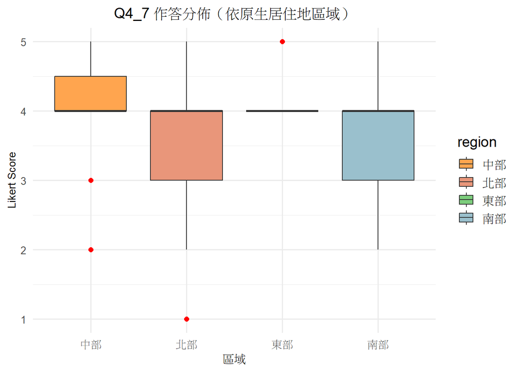

從盒鬚圖來看，每個區域的中位數皆為 4，而分布來說北部和南部的分布接近相同界於 3 ~ 5之間，而東部和中部的圖形較為集中，整體分部落於 4 ~ 5 之間 雖不同區域圖形有些微不同，但整體的分布仍可見相同。

```
## # A tibble: 4 × 9
##   region  mean variance    sd   min    Q1    Q2    Q3   max
##   <chr>  <dbl>    <dbl> <dbl> <dbl> <dbl> <dbl> <dbl> <dbl>
## 1 中部    3.96     0.81  0.9      2     4     4   4.5     5
## 2 北部    3.63     1.11  1.06     1     3     4   4       5
## 3 南部    3.73     0.84  0.92     2     3     4   4       5
## 4 東部    4.2      0.2   0.45     4     4     4   4       5
```

從 Q4_7 題目針對原生居住地區的分析結果來看，各地區學生對「關稅政策導致非必要性商品變貴時是否會調整消費行為」的平均認同度大致相近，皆偏向傾向調整消費行為的立場。東部地區的平均分數最高（4.20），而北部地區最低（3.63），但整體差異不大。

```r
#ANOVA Q4_7 region

anova_result <- aov(response ~ region, data = Q4_7_data)
summary(anova_result)
```

```
##              Df Sum Sq Mean Sq F value Pr(>F)
## region        3   3.62  1.2062   1.214  0.307
## Residuals   153 152.05  0.9938
```

ANOVA 檢定顯示 p 值為 0.307，大於 0.05，表示不同地區間在此題的平均得分並無統計上的顯著差異，亦即居住地區與此項消費調整傾向無明顯關聯。

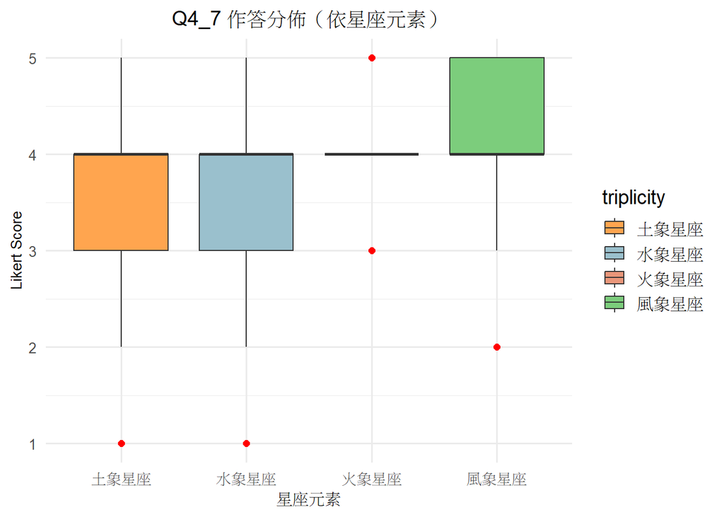

```
## # A tibble: 4 × 9
##   triplicity  mean variance    sd   min    Q1    Q2    Q3   max
##   <chr>      <dbl>    <dbl> <dbl> <dbl> <dbl> <dbl> <dbl> <dbl>
## 1 土象星座    3.5      0.99  0.99     1     3     4     4     5
## 2 水象星座    3.55     1.38  1.18     1     3     4     4     5
## 3 火象星座    4        0.4   0.63     3     4     4     4     5
## 4 風象星座    3.95     0.89  0.94     2     4     4     5     5
```

```r
#ANOVA Q4_7 triplicity

anova_result <- aov(response ~ triplicity, data = Q4_7_data)
summary(anova_result)
```

```
##              Df Sum Sq Mean Sq F value Pr(>F)
## triplicity    3   7.66  2.5533   2.639 0.0516 .
## Residuals   153 148.01  0.9674
## ---
## Signif. codes:  0 '***' 0.001 '**' 0.01 '*' 0.05 '.' 0.1 ' ' 1
```

ANOVA 統計檢定結果顯示，p 值為 0.0516，接近 0.05 的顯著水準邊界，暗示不同星座元素間在此題的平均得分可能存在些微差異，但尚未達到傳統統計意義上的顯著水準。這可能反映出四象在面對消費調整上的態度略有不同，值得進一步探討。